# Homework 5

Jolie Tran

2022-02-17

```r
library(tidyverse)
library(openintro)
library(infer)
```

### Problem 1

Define T = total weight of five randomly selected 1lb. bags of potatoes.

T = X1 + X2 + X3 + X4 + X5, where each Xi has the same normal distribution, $X_i\sim N(1.09, 0.10)$ and the Xi’s are independent.

$T\sim N(\mu_T = 1.09 * 5 = 5.45, \mu_T = \sqrt{(0.10^2)*5}=0.2236)$

Since we want to check the probability that the sum of the weights of the five 1 lb. bags exceeds the weight of one 5 lb. bag, we want to find the distribution of T - Y.

Since $T\sim N(5.45,0.2236)$ and $Y\sim N(5.12,0.18)$ both have the normal distribution, $(T-Y)\sim N(5.45-5.12 = 0.33,\sqrt{0.2236^2+0.18^2}=0.29)$

The probability that the sum of the weights of the five 1 lb. bags exceeds the weight of one 5 lb. bag is P(T-Y > 0) = 0.87

```r
1 - pnorm(0, 0.33, 0.29)
```

```
## [1] 0.8724254
```

### Problem 2

#### Read in Data

```r
ZOD <- read_csv("ZODTwoGroups.csv")
ZOD$Pie <- factor(ZOD$Pie)
```

#### Part a)

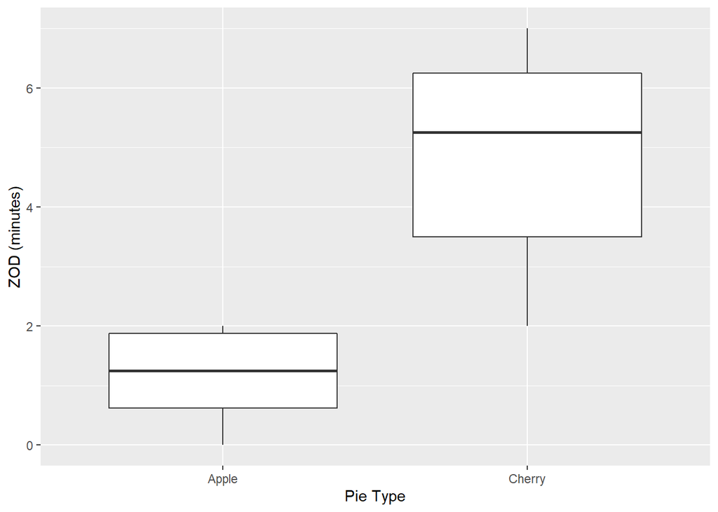

```r
p <- ggplot(ZOD, aes(x = Pie, y = ZOD)) +
  geom_boxplot() + xlab("Pie Type") +
  ylab("ZOD (minutes)")
p
```

Regarding the distribution of each boxplot, both distributions are slightly left skewed and have no apparent outliers.

The boxplot of the Cherry group shows a significantly higher median for ZOD than Apple group’s.

The Cherry group also have a greater variability in ZOD compared to Apple group.

Overall, it shows that the Cherry group have a significantly higher ZOD than Apple group.

#### Part b)

```r
set.seed(25)
PermsOut <- ZOD %>%
  rep_sample_n(size = nrow(ZOD), reps = 1000, replace = FALSE) %>%
  mutate(ZOD_perm = sample(ZOD)) %>%
  group_by(replicate, Pie) %>%
  summarize(prop_ZOD_perm = mean(ZOD_perm), prop_ZOD = mean(ZOD)) %>%
  summarize(diff_perm = diff(prop_ZOD_perm), diff_orig = diff(prop_ZOD))
PermsOut
```

```
## # A tibble: 1,000 x 3
##    replicate diff_perm diff_orig
##        <int>     <dbl>     <dbl>
##  1         1     1          3.67
##  2         2     1.83       3.67
##  3         3     1          3.67
##  4         4     0          3.67
##  5         5     0.5        3.67
##  6         6     0.667      3.67
##  7         7    -3.67       3.67
##  8         8     1.83       3.67
##  9         9    -1.33       3.67
## 10        10     1          3.67
## # ... with 990 more rows
```

The observed difference in means for the sample data is 3.67.

#### Part c)

The statistical hypotheses are H0: $\mu_{Cherry} - \mu_{Apple} = 0$ HA: $\mu_{Cherry} - \mu_{Apple} > 0$

#### Part d)

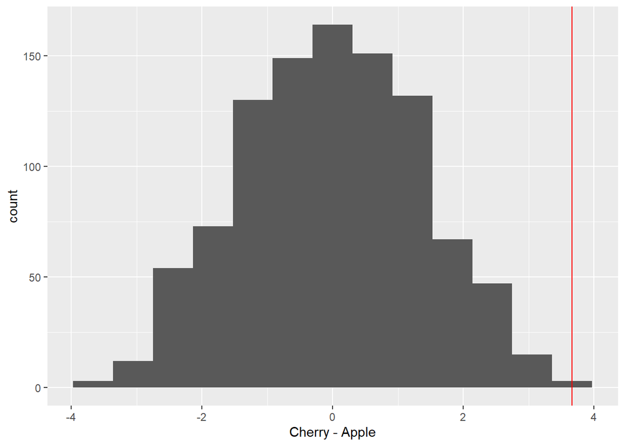

```r
origdiff <- PermsOut$diff_orig[1]
p1 <- ggplot(data = PermsOut, aes(x = diff_perm)) +
  geom_histogram(bins = 13) +
  xlab("Cherry - Apple") +
  geom_vline(xintercept = origdiff, col="Red")
p1
```

The shape of the null distribution is fairly normally distributed.

The observed sample difference is at the very right tail of overall distribution.

#### Part e)

```r
PermsOut %>%
  summarize(count = sum(diff_orig <= diff_perm),
            proportion = mean(diff_orig <= diff_perm))
```

```
## # A tibble: 1 x 2
##   count proportion
##   <int>      <dbl>
## 1     2      0.002
```

The p-value is 0.002.

The p-value (0.002) is the probability of observing a difference of 3.67 or more assuming the proportion of ZOD time does not across the group of student having cherry and student having apple 2 hours before class.

#### Part f)

Since p-value (0.002) is smaller than 0.05, we can reject the null hypothesis in favor of the alternative hypothesis.

### Problem 3

#### Part a)

```r
WL <- read_csv("PopularDietsCombined.csv")
```

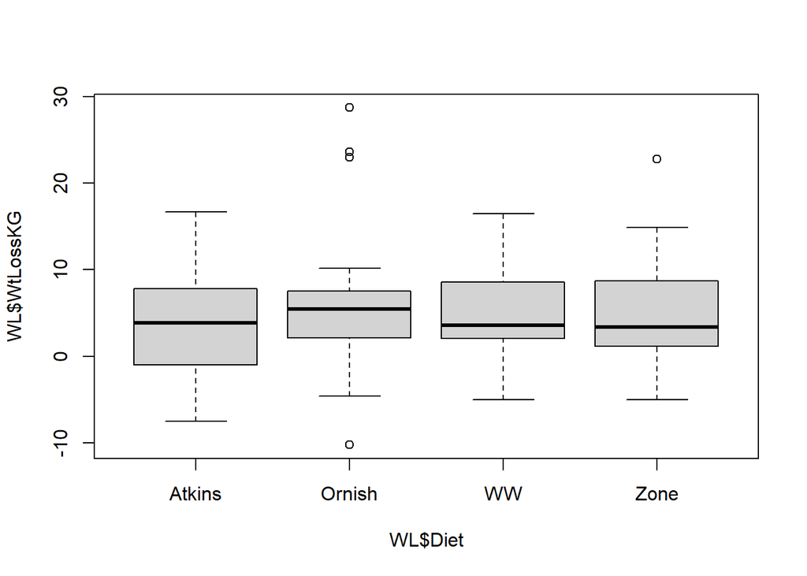

```r
WL$Diet <- factor(WL$Diet)
boxplot(WL$WtLossKG ~ WL$Diet, data = WL)
```

#### Part b)

```r
summary(WL)
```

```
##      Diet       WtLossKG
##  Atkins:21   Min.   :-10.200
##  Ornish:20   1st Qu.:  0.700
##  WW    :26   Median :  3.900
##  Zone  :26   Mean   :  4.945
##              3rd Qu.:  8.400
##              Max.   : 28.700
```

The point estimate for mean weight loss across all diets is $\bar{x}=4.95$

#### Part c)

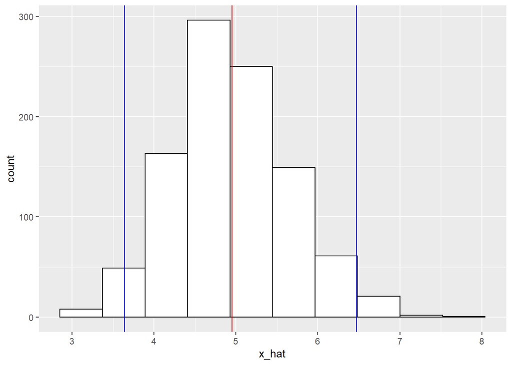

```r
# code for bootstrap samples given; need to add code for histogram
set.seed(25)
# 1000 bootstrap samples so we can display the distribution
BootSamp1000 <- WL %>%  specify(response = WtLossKG) %>%
  generate(reps = 1000, type = "bootstrap") %>%
  calculate(stat = "mean")

# Set the constants for the true mean, and the
# lower and upper confidence bounds for adding
# vertical lines to the graph
TrueMean <- 4.95
LC95 <- sort(BootSamp1000$stat)[25]
UC95 <- sort(BootSamp1000$stat)[975]
# Make a histogram of the bootstrap distribution
B1 <- ggplot(data = BootSamp1000, aes(x = stat )) +
  geom_histogram(bins = 10, colour = 1, fill = "white") +
  xlab("x_hat") + geom_vline(xintercept = TrueMean, col="Red") +
  geom_vline(xintercept = LC95, col="Blue") +
  geom_vline(xintercept = UC95, col="Blue")
B1
```

The bootstrapped distribution for mean weight loss is slightly right skewed with no apparent outlier.

#### Part d)

```r
set.seed(25)
BootSamp1000 %>% get_ci(level = 0.95)
```

```
## # A tibble: 1 x 2
##   lower_ci upper_ci
##      <dbl>    <dbl>
## 1     3.64     6.47
```

get_ci(level = 0.95) returned a lower bound of 3.64 and an upper bound of 6.47. This means that about 95% of our bootstrapped x_hat’s fell between 3.64 and 6.47.

We are 95% confident that the participants who completed the study lose between 3.64 and 6.47 kg.

#### Part e)

```r
#We want to you repeat set.seed for both sets of samples
set.seed(25)
BootSamp1000 %>% get_ci(level = 0.90)
```

```
## # A tibble: 1 x 2
##   lower_ci upper_ci
##      <dbl>    <dbl>
## 1     3.85     6.14
```

```r
set.seed(25)
BootSamp1000 %>% get_ci(level = 0.99)
```

```
## # A tibble: 1 x 2
##   lower_ci upper_ci
##      <dbl>    <dbl>
## 1     3.15     6.86
```

We are 90% confident that the participants who completed the study lose between 3.85 and 6.14 kg.

get_ci(level = 0.99) returned a lower bound of 3.15 and an upper bound of 6.85. This means that about 99% of our bootstrapped x_hat’s fell between 3.15 and 6.86.

We are 99% confident that the participants who completed the study lose between 3.15 and 6.86 kg.

#### Part f)

If we did the entire bootstrap sampling again, the distribution of 1000 x_hat’s would produce a slightly different confidence interval.

#### Part g)

```r
# no set.seed in this part
WL %>%  specify(response = WtLossKG) %>%
  generate(reps = 1000, type = "bootstrap") %>%
  calculate(stat = "mean") %>%
  get_ci(level = 0.95)
```

```
## # A tibble: 1 x 2
##   lower_ci upper_ci
##      <dbl>    <dbl>
## 1     3.64     6.47
```

```r
WL %>%  specify(response = WtLossKG) %>%
  generate(reps = 1000, type = "bootstrap") %>%
  calculate(stat = "mean") %>%
  get_ci(level = 0.95)
```

```
## # A tibble: 1 x 2
##   lower_ci upper_ci
##      <dbl>    <dbl>
## 1     3.58     6.36
```

Yes, these interval do support what I wrote for part f.

We recognize that point estimate can vary from sample to sample. Our confidence interval provides some bounds on the uncertainty due to random sample variation.

If we look at the 95% confidence interval in part d, which is has a lower bound of 3.64 and an upper bound of 6.47, we could see a slight difference here when we draw two new sets of 1000 bootstrap samples using the 93 observations and report the 95% bootstrap confidence interval.

#### Part h)

They will be slightly different that that of 1000 samples.

#### Part i)

```r
set.seed(25)
# 500 bootstrap samples
WL %>%  specify(response = WtLossKG) %>%
  generate(reps = 500, type = "bootstrap") %>%
  calculate(stat = "mean") %>%
  get_ci(level = 0.95)
```

```
## # A tibble: 1 x 2
##   lower_ci upper_ci
##      <dbl>    <dbl>
## 1     3.65     6.51
```

```r
set.seed(25)
# 100 bootstrap samples
WL %>%  specify(response = WtLossKG) %>%
  generate(reps = 100, type = "bootstrap") %>%
  calculate(stat = "mean") %>%
  get_ci(level = 0.95)
```

```
## # A tibble: 1 x 2
##   lower_ci upper_ci
##      <dbl>    <dbl>
## 1     3.74     6.64
```

```r
set.seed(25)
# 10 bootstrap samples
WL %>%  specify(response = WtLossKG) %>%
  generate(reps = 10, type = "bootstrap") %>%
  calculate(stat = "mean") %>%
  get_ci(level = 0.95)
```

```
## # A tibble: 1 x 2
##   lower_ci upper_ci
##      <dbl>    <dbl>
## 1     3.93     6.50
```

Yes, these intervals do support what I wrote for part h.

The difference on these intervals is due to random sample variation.

#### Part j)

```r
# Start by adding code to create the two subsets
WW <- WL %>% filter(Diet == "WW")
Ornish <- WL %>% filter(Diet == "Ornish")

# Add code for first diet
set.seed(25)
WW %>%  specify(response = WtLossKG) %>%
  generate(reps = 1000, type = "bootstrap") %>%
  calculate(stat = "mean") %>%
  get_ci(level = 0.95)
```

```
## # A tibble: 1 x 2
##   lower_ci upper_ci
##      <dbl>    <dbl>
## 1      2.7     6.63
```

```r
# Add code for second diet
set.seed(25)
Ornish %>%  specify(response = WtLossKG) %>%
  generate(reps = 1000, type = "bootstrap") %>%
  calculate(stat = "mean") %>%
  get_ci(level = 0.95)
```

```
## # A tibble: 1 x 2
##   lower_ci upper_ci
##      <dbl>    <dbl>
## 1     2.82     10.8
```

The two diets have a slightly similar lower bound, but Ornish diet have a much greater upper bound compared to that of WW.

We are 95% confident that the participants who completed the WW diet lose between 2.7 and 6.63 kg, and those who completed the Ornish diet lose between 2.82 and 10.77 kg.

…